# Profile and behavior of users of the Bay Wheels bike share service

## by Mayke Ilzu

## Investigation Overview

In this analysis I wanted to understand the profile and behavior of Bay Wheels users, which is a regional public bicycle sharing system. For this, I focused on the understanding of: user type, gender and day of week that the service was used. Some features served as support to understand the aforementioned focus, such as: trip duration, user age and trip start and end hour.

## Dataset Overview

The data consisted of 183412 trip records, containing features that can be divided into three types of information: Route, Location and Customers.

## What is the profile of the users ?

When investigating the data, we noticed that the largest share of users are subscribers. Only **9.3%** of customers who used the service are **occasional customers**.

Users are **mostly male**, but this may not be a particularity of service users, since we do **not know the gender distribution in the city**.

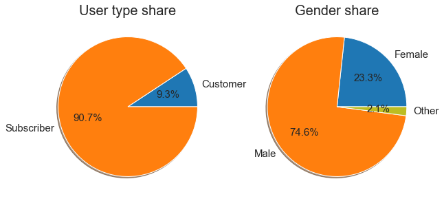

```python
plt.figure(figsize=[10, 5])
plt.subplot(1, 2, 1)

total = df_bay_clean.count()['duration_sec']
df_group = df_bay_clean.groupby('user_type').count()['duration_sec'].reset_index()
df_group['pct'] = df_group['duration_sec'] / total * 100
labels = df_group['user_type']
sizes = df_group['pct']
colors = ['tab:blue','tab:orange','tab:olive']
plt.pie(x=sizes, autopct="%.1f%%", labels=labels,textprops={'fontsize': 15},shadow=True, colors=colors)
plt.title("User type share", fontsize=20);

plt.subplot(1, 2, 2)

total = df_bay_clean.count()['duration_sec']
df_group = df_bay_clean.groupby('member_gender').count()['duration_sec'].reset_index()
df_group['pct'] = df_group['duration_sec'] / total * 100
labels = df_group['member_gender']
sizes = df_group['pct']
plt.pie(x=sizes, autopct="%.1f%%", labels=labels,textprops={'fontsize': 15},shadow=True, colors=colors)
plt.title("Gender share", fontsize=20);
```

## What are the times when the service is most used?

As highlighted in the chart below, we can identify 2 peak times for bike sharing start hour: from 8 am to 9 am and 5 pm to 6 pm. If we evaluate end date the distribution is practically the same as bike sharing usually lasts an average of 9 minutes.

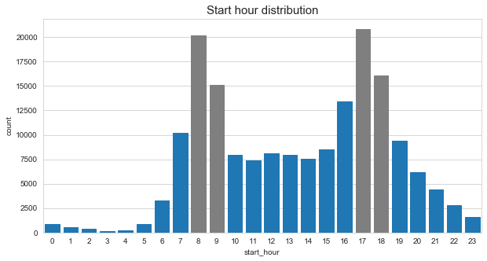

```python
plt.figure(figsize=[10, 5])
ax = sb.countplot(data=df_bay_clean,x='start_hour',color=color)
for bar in ax.patches:
    if bar.get_height() > 15000:
        bar.set_color('tab:gray')
    else:
        bar.set_color('tab:blue')
plt.title('Start hour distribution',fontsize=15);
```

## Are the peak times the same for both user types ?

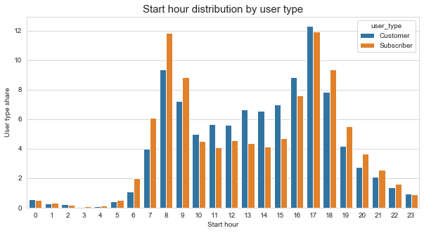

```python
#Calculating percentage to facilitate hourly distribution analysis by user type
df_group = df_bay_clean.groupby(['user_type','start_hour']).agg({'duration_sec': 'count'})
user = df_bay_clean.groupby(['user_type']).agg({'duration_sec': 'count'})
df_group = df_group.div(user, level='user_type') * 100
df_group = df_group.reset_index()

#plot
fig, ax = plt.subplots(figsize=[10,5])
sb.barplot(data=df_group,x='start_hour',y='duration_sec', hue='user_type')
ax.set_xlabel('Start hour')
ax.set_ylabel('User type share')
plt.title('Start hour distribution by user type',fontsize=15);
```

## Does the day of the week and time when the service is used vary according to the user type ?

Here we confirm that the peak usage time during the week is practically the same for both types of users. However, there is a difference between the types of users at the weekend: occasional customers use the service more, especially between 10:00 and 17:00. This reinforces the idea that these customers are the ones who most use the service for leisure

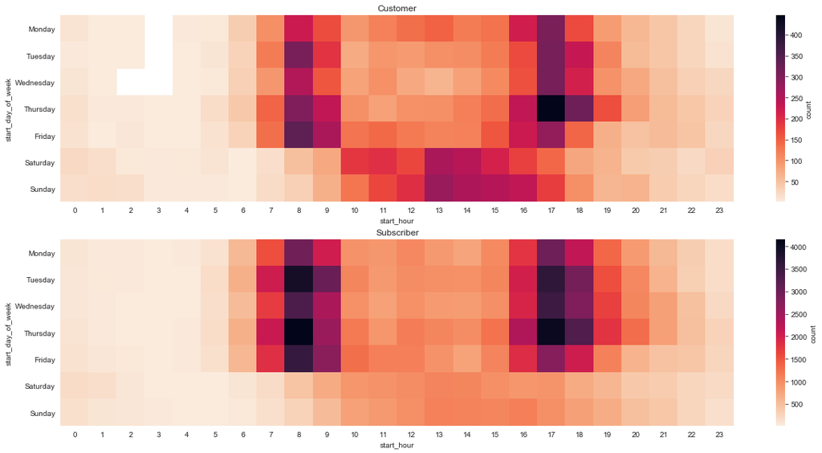

```python
fig, ax = plt.subplots(figsize=[20,10])

plt.subplot(2, 1, 1)
df_filter = df_bay_clean[df_bay_clean['user_type']=='Customer']
df_group = df_filter.groupby(['start_hour', 'start_day_of_week']).count()['duration_sec']
df_group = df_group.reset_index(name = 'count')
df_group = df_group.pivot(index = 'start_day_of_week', columns = 'start_hour',
                            values = 'count')
sb.heatmap(df_group, cbar_kws = {'label' : 'count'},cmap='rocket_r')
plt.title('Customer')

plt.subplot(2, 1, 2)
df_filter = df_bay_clean[df_bay_clean['user_type']=='Subscriber']
df_group = df_filter.groupby(['start_hour', 'start_day_of_week']).count()['duration_sec']
df_group = df_group.reset_index(name = 'count')
df_group = df_group.pivot(index = 'start_day_of_week', columns = 'start_hour',
                            values = 'count')
sb.heatmap(df_group, cbar_kws = {'label' : 'count'},cmap='rocket_r')
plt.title('Subscriber');
```